# Homework 2 Solution

## A touch of R basics

#### Question 1 (10 points)

If you look at lecture 2, we imported several datasets into R. For this homework, you need to import the gapminder data into R. It is available on the class website as `gapminder.csv`. Save the file in the `data` folder of the class RStudio Project you created. You will use the `import` function from the `rio` package. When you’re done, change “eval=F” to “eval=T” in the options for the code chunk

```r
## Fill in the blanks
library(rio)
gapm <- import("data/gapminder.csv")
```

We need to do the `library()` call to activate the package, so that R knows where to look for the function.

*Answer:*

You get an error: `Error in import("data/gapminder.csv") : could not find function "import"`

This error is always indicative of the fact that some package was not loaded, or you’ve spelled the function wrong.

## Visualizing the gapminder dataset

#### Question 2 (20 points)

Let’s look at population growth over time.

```r
ggplot(data = gapm,
       mapping = aes(x = year, y = pop))+
  geom_line(color = country, show.legend = F)+
  scale_y_log10()
```

```
## Error in layer(data = data, mapping = mapping, stat = stat, geom = GeomLine, : object 'country' not found
```

Oops!! This doesn’t quite work.

**a.** Update the code above so that the following plot is rendered.

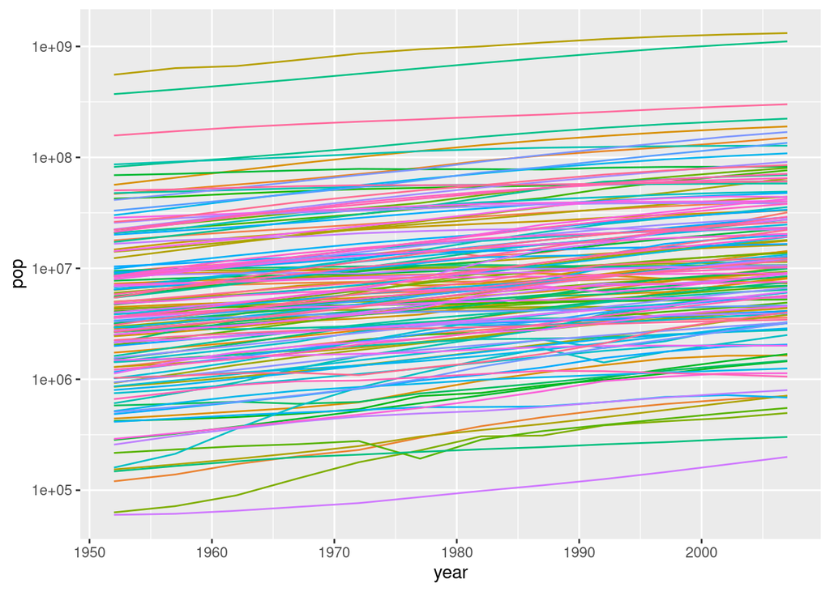

```r
ggplot(data = gapm,
       mapping = aes(x = year, y = pop))+
  geom_line(aes(color = country), show.legend = F)+
  scale_y_log10()
```

**b.** This has too many colors, in my opinion. Lets just color the lines by continent rather than country, and allow the legend to also be drawn. The desired plot is as follows:

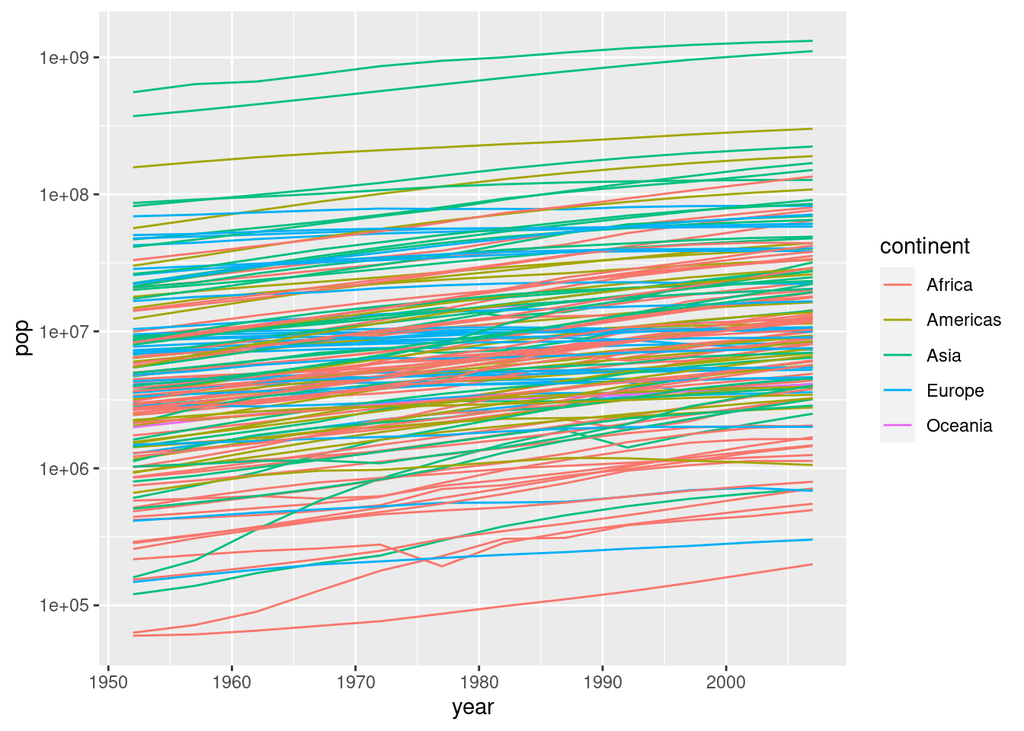

```r
ggplot(data = gapm,
       mapping = aes(x = year, y = pop))+
  geom_line(aes(color = continent, group = country), show.legend = T)+
  scale_y_log10()
```

*Hint: you need to use both group and color, possibly with different variables in the data set*

**c.** This is still too messy. Let’s just separate out the continents and see the population growth by country.

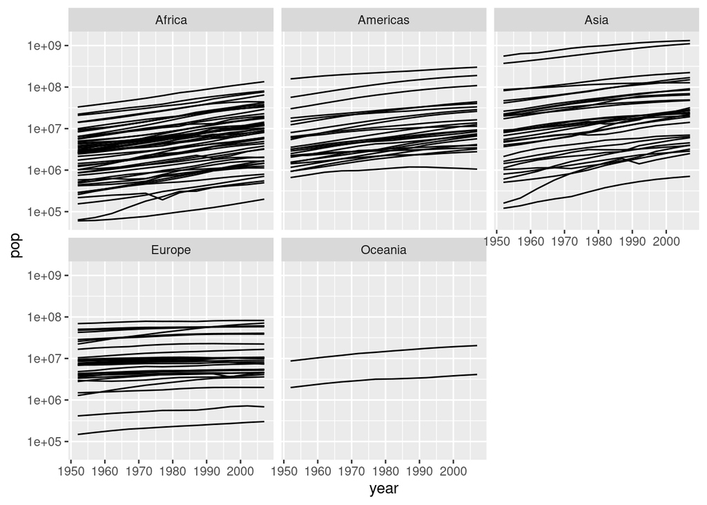

```r
ggplot(data = gapm,
       aes(year, pop))+
  geom_line(aes(group = country)) +
  facet_wrap(~continent)+
  scale_y_log10()
```

**d.** Okay. Let’s go with this as the final graph. Let’s clean it up with proper labels on the x- and y-axes, changing the numbers on the y-axis from scientific notation to usual numbers, and adding a title. The layers you’ll need to add involve

- `labs(x = ___, y = ___)` for the x and y labels
- adding an option to the `scale_y_log10` function (see the lecture)
- `ggtitle` to add a title
- You can also change the theme to something else if you like.

[figure not shown]

```r
ggplot(data = gapm,
       aes(year, pop))+
  geom_line(aes(group = country)) +
  facet_wrap(~continent)+
  scale_y_log10(labels = scales::comma_format()) +
  labs(x = 'Year', y = 'Population')+
  ggtitle('Change in population by country', subtitle='1952-2003')+
  theme(axis.text.x = element_text(size=8))
```

#### Question 3 (20 points)

Now, let’s look at the relationship between per capita GDP of a country and the life expectancy in the country in the gapminder dataset. The final visualization will mimic (with more limited data) a famous visualization that was shown in the Hans Rosling video *[The Joy of Stats](https://www.youtube.com/watch?v=jbkSRLYSojo)*

Let’s start out by plotting the life expectancy against per capita GDP in a scatter plot

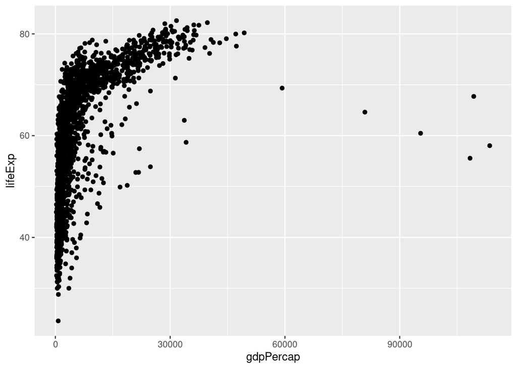

```r
ggplot(gapm, aes(x = gdpPercap, y = lifeExp)) +
  geom_point()
```

**a.** Change the x-axis to display on the log scale  
**b.** Change the size of the points to reflect the square root (the R function is `sqrt`) of the population  
**c.** Color the inside of each point by continent  
**d.** Separate the graphs out by year (use `facet_wrap`)

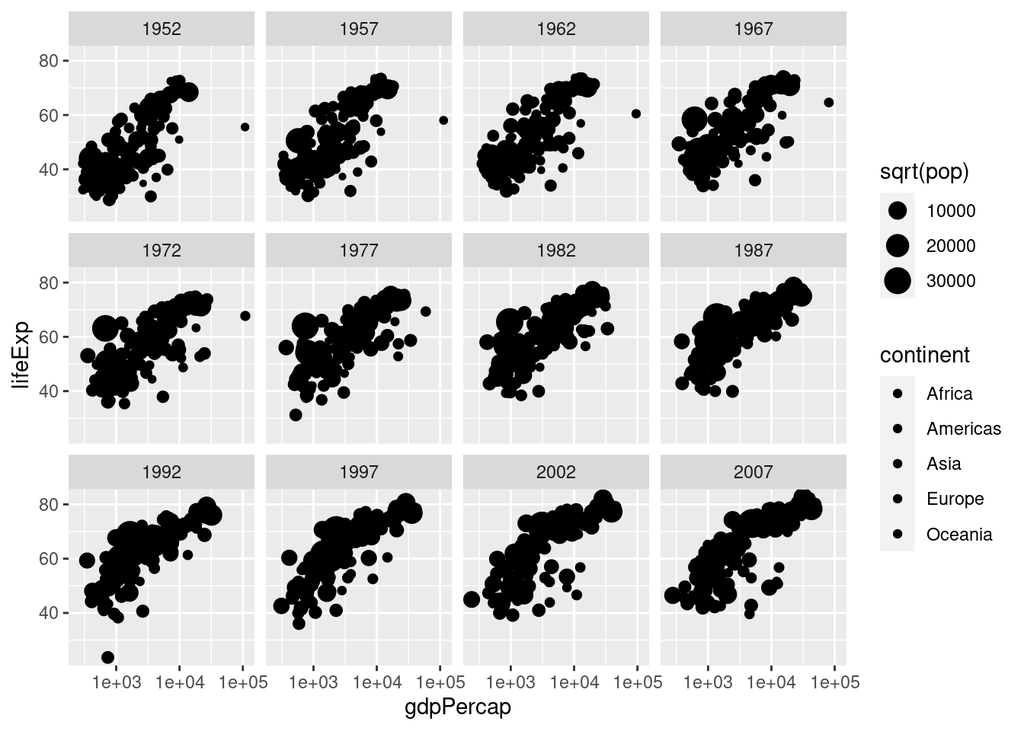

```r
ggplot(gapm, aes(x = gdpPercap, y = lifeExp)) +
  geom_point(aes(size = sqrt(pop), fill=continent)) +
  scale_x_log10()+
  facet_wrap(~year)
```

#### Extra credit (10 points)

Make the following visualization using `gganimate` based on the plot you developed in Question 3. Note that it might take a minute, literally, for the animation to render.

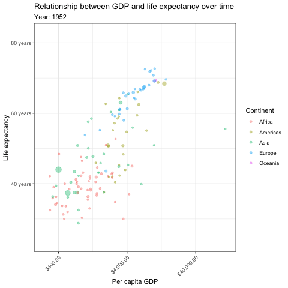

```r
library(gganimate)
plt <- ggplot(gapm, aes(x = gdpPercap, y = lifeExp))+
  geom_point(aes(size = pop, color = continent), alpha = 0.4, show.legend=T)+
  scale_x_log10(breaks = c(400, 4000, 40000), labels = scales::dollar_format()) +
  scale_y_continuous(breaks = c(40, 60, 80), labels = paste(c(40,60,80), 'years'))+
  # facet_wrap(~year) +
  scale_size_continuous('Population', labels = scales::label_number_si(accuracy = 0.1))+
  guides(size = FALSE)+
  labs(x = "Per capita GDP", y = "Life expectancy", color = 'Continent')+
  theme_bw() +
  theme(axis.text.x = element_text(angle=45, hjust = 1))+
  ggtitle('Relationship between GDP and life expectancy over time')
plt + labs(subtitle='Year: {frame_time}') + transition_time(year) + ease_aes('linear')
anim_save('hw2_img/HW2-11-1.gif')
```